# Workshop Spatial Data - Datathon KUL 2020

Romaike Middendorp (Data Scientist at XploData)

17-02-2020

## Introduction

This notebook provides a quick starting point for participants of the Datathon KUL 2020 working with spatial data. This notebooks covers the very basics of handling spatial data in R and is accompanied by a workshop on Monday 17 February at the KUL.

This notebooks uses spatial data from three data sources: Telraam data on traffic, Leuvenair data on air quality and Garmon weather data. All data and additional information concerning the data can be found at: https://lstat.kuleuven.be/Datathon2020/data.

## Spatail data objects in R

### Telraam data

You’ll start by retrieving the active road segments in the Telraam data. These data can be accessed through this API: https://telraam-api.net/.

Active road segments are available in GeoJSON format. We load the data directly using the `sf` package, which is the successor of the well-established `sp` package. It does a great job at handling spatial data (also in GeoJSON format). The `st_read` function creates a data frame with a geometry list-column.

```r
# Load libraries
library(tidyverse)
library(sf)
# Create URL and read road segment data as sf object
url <- "https://telraam-api.net/v0/segments/active"
active_sf <- st_read(url)
class(active_sf)
```

```
## [1] "sf"         "data.frame"
```

We can visualize the road segments, using the `tmap` package. Assign the spatial object to the `tm_shape` function and add a mapping from visual properties to variables. Here we map the number of cars that passed by in the last hour to the `col` argument. To create an interactive html map, use the `view` mode.

```r
# Load library
library(tmap)

# Set mode to view
tmap_mode('view')
```

```
## tmap mode set to interactive viewing
```

```r
# Set spatial object and type
tm_shape(active_sf) +
  tm_lines(col = "car", scale = 3)
```

[interactive chart not shown]

Telraam contains road segments over the whole of Flanders. Presumable, you’ll be interested in only the roads that are located in the city of Leuven. To filter out road segments outside of Leuven, you can use the method intersect.

First, let’s get the spatial boundaries of the city of Leuven. GADM is a useful open source that provides maps and spatial data for all countries and their sub-divisions: https://gadm.org/download_country_v3.html.

```r
municipalities <- readRDS("data/gadm36_BEL_4_sf.rds")
leuven <- municipalities %>% filter(NAME_4 == "Leuven")
summary(leuven)
```

```
##     GID_0              NAME_0             GID_1
##  Length:1           Length:1           Length:1
##  Class :character   Class :character   Class :character
##  Mode  :character   Mode  :character   Mode  :character
##     NAME_1             GID_2              NAME_2
##  Length:1           Length:1           Length:1
##  Class :character   Class :character   Class :character
##  Mode  :character   Mode  :character   Mode  :character
##     GID_3              NAME_3             GID_4
##  Length:1           Length:1           Length:1
##  Class :character   Class :character   Class :character
##  Mode  :character   Mode  :character   Mode  :character
##     NAME_4           VARNAME_4            TYPE_4
##  Length:1           Length:1           Length:1
##  Class :character   Class :character   Class :character
##  Mode  :character   Mode  :character   Mode  :character
##   ENGTYPE_4             CC_4                    geometry
##  Length:1           Length:1           MULTIPOLYGON :1
##  Class :character   Class :character   epsg:4326    :0
##  Mode  :character   Mode  :character   +proj=long...:0
```

Now, we can filter the active road segments using the boundaries of Leuven from GADM. There are 133 unique active road segments in Leuven.

```r
active_leuven <- active_sf[leuven, op = st_intersects]
```

```
## although coordinates are longitude/latitude, st_intersects assumes that they are planar
```

```r
length(unique(active_leuven$id))
```

```
## [1] 133
```

```r
# Remove duplicate roads
active_leuven <- active_leuven %>%
  arrange(id, last_data_package) %>%
  distinct(active_leuven, id, .keep_all = TRUE)
```

A new road segments `sf` object now only contains roads for the city of Leuven. You can map these with `tmap`.

```r
# Load library
library(tmap)
tmap_mode('view')
```

```
## tmap mode set to interactive viewing
```

```r
tm_shape(active_leuven) +
  tm_lines(col = "car", scale = 3)
```

[interactive chart not shown]

### Retrieve Telraam reports for road segments in Leuven

Now that you have the spatial data for road segments loaded into R, you can take a look at the observed traffic on these roads.

The Telraam API provides reports with hourly observations on traffic for each segment. You can write a `for` loop to retrieve hourly reports for a given time interval for all the segment IDs in Leuven.

```r
library(jsonlite)
library(httr)
# First get a list of segment IDs in Leuven
segment_ids_leuven <- unique(active_leuven$id)

# Set the parameters for the POST request
headers <- c("Content-Type" = "application/json")

params <- '{
    "time_start": "2019-12-01 00:00",
    "time_end": "2019-12-07 23:59",
    "level": "segments",
    "format":"per-hour"
}'

# Initialize an empty data frame to store the Telraam data
reports <- data.frame()

# For each segment ID in Leuven do:
for (i in 1:length(segment_ids_leuven)){
  # build a request for each segment id:
  request <- httr::POST(url = paste0("https://telraam-api.net/v0/reports/", segment_ids_leuven[i]),
    httr::add_headers(.headers = headers), body = params)
  # retrieve the API response
  response <- content(request, "text", encoding = "UTF-8")
  # flatten the data into a temporary data frame
  report_tmp <- fromJSON(response, flatten = TRUE) %>%
    data.frame()
  # bind the retrieved data into final data frame
  reports <- rbind(reports, report_tmp)
}

# Clean the column names
names(reports) <- str_replace(names(reports), "report.", "")

# Convert segment IDs to numeric (in stead of character)
reports <- reports %>%
  mutate(segment_id = as.numeric(segment_id))

# Check out your work!
head(reports)
```

```
##   segment_id             date pct_up pedestrian bike car lorry
## 1      80828 2019-12-01 09:00   0.33          0    0  15     0
## 2      80828 2019-12-01 10:00   0.79          1   13  25     2
## 3      80828 2019-12-01 11:00   0.79          4    4  19     0
## 4      80828 2019-12-01 12:00   0.79          2   19  22     4
## 5      80828 2019-12-01 13:00   0.79          0    4  24     0
## 6      80828 2019-12-01 14:00   0.79          0   13  28     3
##   pedestrian_lft bike_lft car_lft lorry_lft pedestrian_rgt bike_rgt
## 1              0        0      12         0              0        0
## 2              0        4       5         1              1        9
## 3              0        0       1         0              4        4
## 4              1       10       0         0              1        9
## 5              0        4       4         0              0        0
## 6              0       10       3         0              0        3
##   car_rgt lorry_rgt car_speed_histogram car_speed_bucket
## 1       3         0               4, 13             1, 2
## 2      20         1         4, 7, 13, 3       0, 1, 2, 3
## 3      18         0            2, 17, 2          1, 2, 3
## 4      22         4               3, 20             1, 2
## 5      20         0      2, 6, 13, 4, 2    0, 1, 2, 3, 4
## 6      25         3         6, 17, 6, 2       1, 2, 3, 4
```

```r
# Clean the date time value using the lubridate ymd_hm function
library(lubridate)
reports$date <- ymd_hm(reports$date, tz = "Europe/Paris")

# Get data in tidy format, by transforming the wide data frame to a long with count per 'vehicile' type
reports_long <- reports %>%
  select(1:7) %>%
  gather(key = "type", value = "count", 4:7)
head(reports_long)
```

```
##   segment_id                date pct_up       type count
## 1      80828 2019-12-01 09:00:00   0.33 pedestrian     0
## 2      80828 2019-12-01 10:00:00   0.79 pedestrian     1
## 3      80828 2019-12-01 11:00:00   0.79 pedestrian     4
## 4      80828 2019-12-01 12:00:00   0.79 pedestrian     2
## 5      80828 2019-12-01 13:00:00   0.79 pedestrian     0
## 6      80828 2019-12-01 14:00:00   0.79 pedestrian     0
```

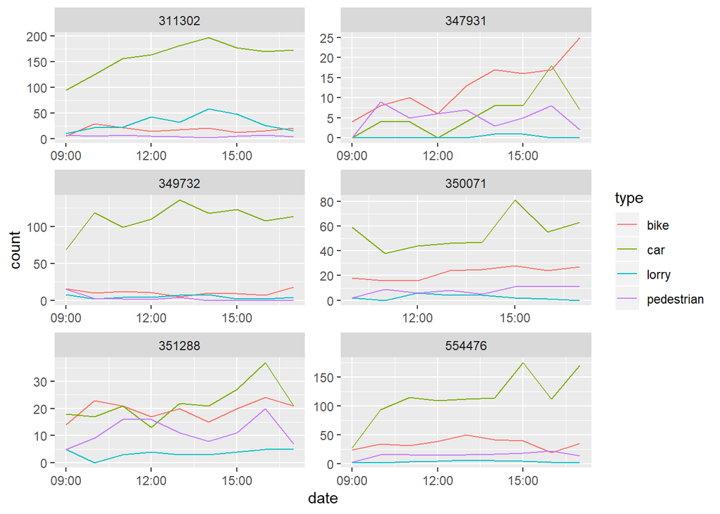

```r
# Sample 6 random segmets for plotting
sample_segments <- sample(reports$segment_id, 6)

# Filter the reports on day and segment_id to show only a subset of all data
reports_long_sub <- reports_long %>%
  filter(day(date) == 1 & segment_id %in% sample_segments)

# Plot date vs. traffic count, assign the color the the 'vehicile' type. Use facet wrap on segment id to get a plot per street segment
ggplot(reports_long_sub, aes(x = date, y = count, col = type)) +
  geom_line() +
  facet_wrap(~segment_id, ncol = 2, scales = "free")
```

### Leuvenair data

Data collected by 116 sensors in and around Leuven are collected over two years. These data can be downloaded via this link: https://data.leuvenair.be/data-l.html.

The locations of air stations can be retrieved from the online JSON file and converted to a `sf` object by assigning the latitude and longitude coordinate columns in `st_as_sf` function. Keep stations where export equals 1.

```r
air_stations <- fromJSON("https://data.leuvenair.be/data/LEUVENAIRmeta_final.json")

# Select only where Export = 1 and convert to sf object
air_stations <- air_stations %>%
  mutate_at(c(1:5, 11:17), as.numeric) %>% #'SDS011ID', 'INDUSTRY', 'WOODSTOVES', 'TRAFFIC', 'SVL', 'NO2_CN'
  filter(EXPORT == 1) %>%
  st_as_sf(coords = c('LON', 'LAT'))

summary(air_stations)
```

```
##     SDS011ID         DHTID           EXPORT     GMAPS
##  Min.   : 6561   Min.   : 8746   Min.   :1   Length:108
##  1st Qu.: 8820   1st Qu.: 8823   1st Qu.:1   Class :character
##  Median : 9574   Median : 9580   Median :1   Mode  :character
##  Mean   :10740   Mean   :10811   Mean   :1
##  3rd Qu.: 9670   3rd Qu.: 9778   3rd Qu.:1
##  Max.   :30627   Max.   :30628   Max.   :1
##                  NA's   :1
##     MADAVI             STREET           POSTALCODE
##  Length:108         Length:108         Length:108
##  Class :character   Class :character   Class :character
##  Mode  :character   Mode  :character   Mode  :character
##
##
##
##
##      CITY            HEIGHT (cm)     SENSOR POSITION     INDUSTRY
##  Length:108         Min.   :  50.0   Min.   : 1.000   Min.   : 1.000
##  Class :character   1st Qu.: 250.0   1st Qu.: 8.000   1st Qu.: 1.000
##  Mode  :character   Median : 300.0   Median :10.000   Median : 1.000
##                     Mean   : 348.8   Mean   : 8.282   Mean   : 1.903
##                     3rd Qu.: 395.0   3rd Qu.:10.000   3rd Qu.: 2.000
##                     Max.   :1700.0   Max.   :20.000   Max.   :10.000
##                     NA's   :5        NA's   :5        NA's   :5
##    WOODSTOVES        TRAFFIC            SVL             NO2_CN
##  Min.   : 1.000   Min.   : 1.000   Min.   :0.0000   Min.   :16.42
##  1st Qu.: 2.000   1st Qu.: 3.000   1st Qu.:0.0000   1st Qu.:20.33
##  Median : 3.000   Median : 6.000   Median :1.0000   Median :23.49
##  Mean   : 3.709   Mean   : 5.806   Mean   :0.7315   Mean   :25.39
##  3rd Qu.: 5.000   3rd Qu.: 8.000   3rd Qu.:1.0000   3rd Qu.:28.33
##  Max.   :10.000   Max.   :10.000   Max.   :1.0000   Max.   :44.47
##  NA's   :5        NA's   :5                         NA's   :52
##     geometry
##  POINT  :108
##  epsg:NA:  0
##
##
##
##
##
```

The Coordinate Reference System (CRS) of air stations is empty. You can assign it to WGS84 latitude/longitude coordinates.

```r
st_crs(air_stations) <- "+proj=longlat +datum=WGS84 +no_defs"
```

There are duplicate air stations and not all stations are present in the air data from December 2019.

```r
length(unique(air_stations$SDS011ID))
```

```
## [1] 106
```

```r
air_stations %>% group_by(SDS011ID) %>% filter(n() > 1) %>% head()
```

```
## Simple feature collection with 4 features and 15 fields
## geometry type:  POINT
## dimension:      XY
## bbox:           xmin: 4.696 ymin: 50.855 xmax: 4.7008 ymax: 50.8914
## epsg (SRID):    4326
## proj4string:    +proj=longlat +datum=WGS84 +no_defs
## # A tibble: 4 x 16
## # Groups:   SDS011ID [2]
##   SDS011ID DHTID EXPORT GMAPS MADAVI STREET POSTALCODE CITY  `HEIGHT (cm)`
##      <dbl> <dbl>  <dbl> <chr> <chr>  <chr>  <chr>      <chr>         <dbl>
## 1     8799  8800      1 "<a ~ "<a h~ Klein~ 3012       Wils~           390
## 2     8799  8800      1 "<a ~ "<a h~ Klein~ 3012       Wils~           390
## 3     8827  8828      1 "<a ~ "<a h~ Naams~ 3001       Heve~           400
## 4     8827  8828      1 "<a ~ "<a h~ Broek~ 3001       Heve~           400
## # ... with 7 more variables: `SENSOR POSITION` <dbl>, INDUSTRY <dbl>,
## #   WOODSTOVES <dbl>, TRAFFIC <dbl>, SVL <dbl>, NO2_CN <dbl>,
## #   geometry <POINT [°]>
```

```r
# Filter out duplicate station IDs by selecting only first row grouped per sensor ID
air_stations <- air_stations %>%
  filter(SDS011ID %in% unique(air_stations$SDS011ID)) %>%
  group_by(SDS011ID) %>%
  filter(row_number()==1)
```

With the `leaflet` package you can quickly create an interactive plot of air stations on an Open Street Map background to see were stations are located. By using the `addCircleMarkers` and assigning the air stations, the locations are plotted as dots on the map.

```r
library(leaflet)
library(htmltools)
leaflet() %>%
  addTiles(group = "OSM") %>%
  addCircleMarkers(data = air_stations, radius = 2, label = ~paste0('Station ID: ', htmlEscape(SDS011ID)),
                   color = 'darkblue')
```

[interactive chart not shown]

```r
tmap_mode('view')
```

```
## tmap mode set to interactive viewing
```

```r
tm_shape(active_leuven) +
  tm_lines(col = "car", scale = 3) +
  tm_shape(air_stations) +
  tm_dots(col = 'darkblue')
```

[interactive chart not shown]

### Leuvenair P2.5 measurements

The spatial data on Leuvenair stations is loaded into R. Time to look at the air quality measurements. You start here with the full data dump from 2019. Given the amount of observations and the memory limitations of R run on your personal laptop, you can start by filtering the data to a selected time interval. By cleaning the `DATEUTC` variable to a date time format allows you to filter on the first week of December 2019.

```r
# Read in the full data dump 2019
air <- read.csv('data/LEUVENAIRfulldump2019.csv', stringsAsFactors = FALSE)

# Subset airquality data to the first week of december
air <- air %>%
  mutate(DATEUTC = ymd_hms(DATEUTC, tz = "UTC")) %>%
  filter(month(DATEUTC) == 12 & day(DATEUTC) %in% c(1:7)) %>% #%in% c(1:5)
  arrange(SDS011ID, DATEUTC)
str(air)
```

```
## 'data.frame':    251343 obs. of  10 variables:
##  $ DATEUTC    : POSIXct, format: "2019-12-01 00:01:50" "2019-12-01 00:04:15" ...
##  $ LAT        : num  50.9 50.9 50.9 50.9 50.9 ...
##  $ LON        : num  4.72 4.72 4.72 4.72 4.72 ...
##  $ SDS011ID   : int  6561 6561 6561 6561 6561 6561 6561 6561 6561 6561 ...
##  $ PM2.5      : num  12.7 12.9 13.5 13.2 13.3 13.9 13.1 12 13.1 13.8 ...
##  $ PM10       : num  27.2 28.8 28.6 31.7 29.8 36 24.4 24.6 32 28.3 ...
##  $ DHTID      : int  NA NA NA NA NA NA NA NA NA NA ...
##  $ TEMPERATURE: num  NA NA NA NA NA NA NA NA NA NA ...
##  $ HUMIDITY   : num  NA NA NA NA NA NA NA NA NA NA ...
##  $ OBSID      : int  29088433 29088486 29088540 29088545 29088590 29088638 29088685 29088743 29088792 29088837 ...
```

```r
# Quick plot of measurements at one random station for december
sample_air <- sample(air$SDS011ID, 6)
sample_air
```

```
## [1] 12855  9621 15986 19832  8813 22953
```

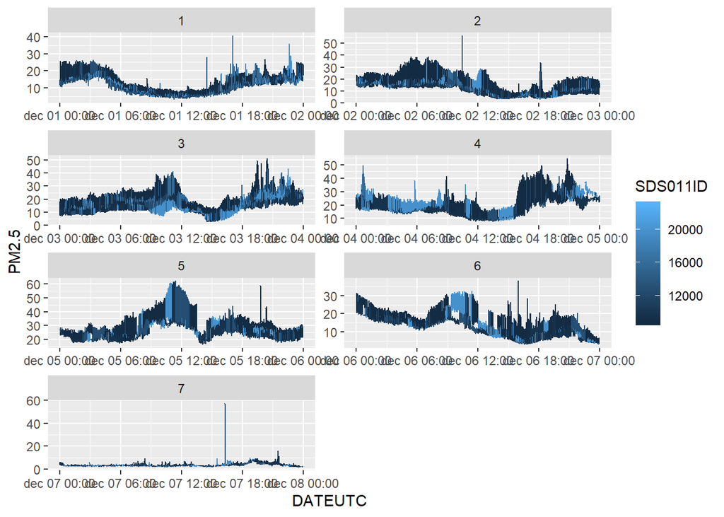

```r
air %>%
  filter(SDS011ID %in% sample_air) %>%
  ggplot(aes(x = DATEUTC, y = PM2.5, color = SDS011ID)) +
  geom_line() +
  facet_wrap(~day(DATEUTC), ncol = 2, scales = "free")
```

The observations from the different stations come from irregular time intervals. Additionally, we see some unusal high peaks in the PM2.5 measurements for some stations that were not measured in oter stations.

You start with cleaning and aggregating the Leuvenair data so that you could later join them to other data sources for analysis. First, create a date time vector with regular time intervals per second starting at 1 December through 7 December (i.e., the selected time interval). You cap high PM2.5 observations off at an arbitrary value of 125 to prevent visualizations from looking skewed. This is not a correct way to treat these ‘outlier’ measurements and you should tink about a better way to deal with these outliers.

```r
# Crete a regular time interval of seconds between 1 Dec - 7 Dec
dt_seq <- seq(as.POSIXct("2019-12-01 00:00:00 UTC"),
              as.POSIXct("2019-12-07 23:59:59 UTC"),
              by = 1)
head(dt_seq)
```

```
## [1] "2019-12-01 00:00:00 CET" "2019-12-01 00:00:01 CET"
## [3] "2019-12-01 00:00:02 CET" "2019-12-01 00:00:03 CET"
## [5] "2019-12-01 00:00:04 CET" "2019-12-01 00:00:05 CET"
```

```r
# Arbitrary capping off PM2.5 measurements above 100 to 100
air <- air %>%
  mutate(PM2.5 = ifelse(PM2.5 > 125, 125, PM2.5))
```

You then create a data frame with the regular second interval sequence for each of the sensor IDs in the Leuvenair data. Then you join the full date time data frame to the Leuvenair data using `left_join`. There are a lot of blanks, but you will solve this in the next step.

```r
air_full <- data.frame(DATEUTC = dt_seq,
                  SDS011ID = rep(unique(air$SDS011ID), each = length(dt_seq))) %>%
  left_join(air[, c(1,4,5)], by = c("DATEUTC", "SDS011ID"))
head(air_full)
```

```
##               DATEUTC SDS011ID PM2.5
## 1 2019-11-30 23:00:00     6561    NA
## 2 2019-11-30 23:00:01     6561    NA
## 3 2019-11-30 23:00:02     6561    NA
## 4 2019-11-30 23:00:03     6561    NA
## 5 2019-11-30 23:00:04     6561    NA
## 6 2019-11-30 23:00:05     6561    NA
```

The regular spaced data frame created above (i.e., time intervals of 1 second) now contains all the observed air quality data of the Leuven sensors. You implement a rolling median over the PM2.5 measurements to obtain the hourly median for station. Here, you use the `rollapply` function from the `zoo` package. This package contains a set of very useful methods to work with time series in R. This step takes quite some time but will reduce the number of observations to keep in memory.

```r
# Load libraries
library(reshape2)
library(zoo)
library(RcppRoll)
# Convert to wide format
PM2.5wide <- dcast(air_full[, c('SDS011ID', 'PM2.5', 'DATEUTC')],
                   DATEUTC ~ SDS011ID,
                   value.var = "PM2.5")
head(PM2.5wide)
```

```
##               DATEUTC 6561 8745 8765 8769 8773 8777 8789 8791 8797 8799
## 1 2019-11-30 23:00:00   NA   NA   NA   NA   NA   NA   NA   NA   NA   NA
## 2 2019-11-30 23:00:01   NA   NA   NA   NA   NA   NA   NA   NA   NA   NA
## 3 2019-11-30 23:00:02   NA   NA   NA   NA   NA   NA   NA   NA   NA   NA
## 4 2019-11-30 23:00:03   NA   NA   NA   NA   NA   NA   NA   NA   NA   NA
## 5 2019-11-30 23:00:04   NA   NA   NA   NA   NA   NA   NA   NA   NA   NA
## 6 2019-11-30 23:00:05   NA   NA   NA   NA   NA   NA   NA   NA   NA   NA
##   8803 8805 8811 8813 8819 8821 8827 8829 8833 8835 8837 8839 8841 8845
## 1   NA   NA   NA   NA   NA   NA   NA   NA   NA   NA   NA   NA   NA   NA
## 2   NA   NA   NA   NA   NA   NA   NA   NA   NA   NA   NA   NA   NA   NA
## 3   NA   NA   NA   NA   NA   NA   NA   NA   NA   NA   NA   NA   NA   NA
## 4   NA   NA   NA   NA   NA   NA   NA   NA   NA   NA   NA   NA   NA   NA
## 5   NA   NA   NA   NA   NA   NA   NA   NA   NA   NA   NA   NA   NA   NA
## 6   NA   NA   NA   NA   NA   NA   NA   NA   NA   NA   NA   NA   NA   NA
##   8849 8853 8859 8993 9563 9567 9569 9571 9577 9579 9585 9587 9593 9597
```

[output cut: 27 more lines]

```r
# Convert to zoo object for timeseries
PM2.5zoo <- zoo(PM2.5wide[,-1], PM2.5wide$DATEUTC)

# Apply rollapply function to calculate hourly median
PM2.5zoo_med <- rollapply(PM2.5zoo, width = 3599,
                          FUN = function(x) median(x, na.rm = TRUE), by = 3600,
                          by.column = TRUE, partial = TRUE, fill = NA, align = "right")

dt_sel <- seq(as.POSIXct("2019-12-01 00:00:00 UTC"),
              as.POSIXct("2019-12-07 23:59:59 UTC"),
              by = (60*60))

# Determine the index at which hourly measruments are in the dataset
ind <- which(index(PM2.5zoo_med) %in% dt_sel)

# Select only these measuremnts
PM2.5zoo_med <- PM2.5zoo_med[ind]
summary(PM2.5zoo_med)
```

```
##      Index                          6561             8745
##  Min.   :2019-11-30 23:00:00   Min.   : 2.100   Min.   : 2.700
##  1st Qu.:2019-12-02 16:45:00   1st Qu.: 6.025   1st Qu.: 8.102
##  Median :2019-12-04 10:30:00   Median :12.325   Median :17.177
##  Mean   :2019-12-04 10:30:00   Mean   :12.146   Mean   :16.465
##  3rd Qu.:2019-12-06 04:15:00   3rd Qu.:16.087   3rd Qu.:23.030
##  Max.   :2019-12-07 22:00:00   Max.   :35.550   Max.   :41.215
##                                NA's   :2        NA's   :2
##       8765            8769             8773             8777
##  Min.   : 2.27   Min.   : 2.400   Min.   : 2.300   Min.   : 3.335
##  1st Qu.: 6.40   1st Qu.: 7.694   1st Qu.: 7.424   1st Qu.:12.953
##  Median :13.50   Median :16.250   Median :15.182   Median :23.593
##  Mean   :12.97   Mean   :16.379   Mean   :14.619   Mean   :23.521
##  3rd Qu.:17.70   3rd Qu.:22.922   3rd Qu.:20.315   3rd Qu.:30.556
##  Max.   :29.90   Max.   :45.150   Max.   :34.330   Max.   :60.935
##  NA's   :11      NA's   :2        NA's   :2        NA's   :16
##       8789             8791             8797             8799
##  Min.   : 2.660   Min.   : 2.230   Min.   : 1.900   Min.   : 2.335
##  1st Qu.: 8.954   1st Qu.: 6.338   1st Qu.: 6.473   1st Qu.: 6.070
##  Median :18.685   Median :14.225   Median :10.643   Median :13.070
##  Mean   :18.001   Mean   :14.918   Mean   :11.748   Mean   :14.876
##  3rd Qu.:25.706   3rd Qu.:21.323   3rd Qu.:14.213   3rd Qu.:21.000
##  Max.   :41.030   Max.   :38.580   Max.   :46.600   Max.   :38.800
##  NA's   :2        NA's   :2        NA's   :2        NA's   :51
##       8803             8805             8811             8813
##  Min.   : 2.430   Min.   : 2.165   Min.   : 2.430   Min.   : 2.87
##  1st Qu.: 8.518   1st Qu.: 6.707   1st Qu.: 8.078   1st Qu.:13.40
##  Median :16.235   Median :13.332   Median :16.080   Median :20.82
##  Mean   :15.482   Mean   :14.877   Mean   :16.099   Mean   :21.07
##  3rd Qu.:21.625   3rd Qu.:22.683   3rd Qu.:22.352   3rd Qu.:27.21
##  Max.   :34.915   Max.   :36.500   Max.   :36.370   Max.   :58.28
##  NA's   :57       NA's   :2        NA's   :2        NA's   :2
##       8819             8821          8827             8829
##  Min.   : 2.170   Min.   : NA   Min.   : 2.270   Min.   : 2.60
##  1st Qu.: 7.941   1st Qu.: NA   1st Qu.: 2.900   1st Qu.: 6.19
##  Median :15.148   Median : NA   Median : 3.230   Median :13.44
##  Mean   :15.803   Mean   :NaN   Mean   : 4.087   Mean   :14.16
##  3rd Qu.:21.966   3rd Qu.: NA   3rd Qu.: 4.322   3rd Qu.:21.48
##  Max.   :45.485   Max.   : NA   Max.   :10.900   Max.   :35.45
##  NA's   :2        NA's   :168   NA's   :138      NA's   :2
```

[output cut: 97 more lines]

```
##  Min.   : NA   Min.   : 1.800   Min.   : 1.650   Min.   : 2.37
##  1st Qu.: NA   1st Qu.: 6.527   1st Qu.: 6.744   1st Qu.:10.32
##  Median : NA   Median :13.715   Median :11.640   Median :22.16
##  Mean   :NaN   Mean   :15.794   Mean   :11.435   Mean   :23.31
##  3rd Qu.: NA   3rd Qu.:24.835   3rd Qu.:15.447   3rd Qu.:31.85
##  Max.   : NA   Max.   :41.080   Max.   :26.700   Max.   :87.30
##  NA's   :168   NA's   :45       NA's   :2        NA's   :2
##      30627
##  Min.   : 2.17
##  1st Qu.:10.06
##  Median :20.15
##  Mean   :23.92
##  3rd Qu.:33.89
##  Max.   :90.23
##  NA's   :2
```

```r
head(index(PM2.5zoo_med))
```

```
## [1] "2019-11-30 23:00:00 UTC" "2019-12-01 00:00:00 UTC"
## [3] "2019-12-01 01:00:00 UTC" "2019-12-01 02:00:00 UTC"
## [5] "2019-12-01 03:00:00 UTC" "2019-12-01 04:00:00 UTC"
```

```r
# Convert to data frame by using the fortify.zoo function
PM2.5_med <- fortify.zoo(PM2.5zoo_med)
head(PM2.5_med)
```

```
##                 Index  6561   8745 8765  8769   8773   8777   8789   8791
## 1 2019-11-30 23:00:00    NA     NA   NA    NA     NA     NA     NA     NA
## 2 2019-12-01 00:00:00    NA     NA   NA    NA     NA     NA     NA     NA
## 3 2019-12-01 01:00:00 13.10 17.365   NA 14.63 14.820 23.100 19.500 17.100
## 4 2019-12-01 02:00:00 14.20 19.450   NA 16.83 16.930 26.530 21.915 17.430
## 5 2019-12-01 03:00:00 15.70 21.335   NA 17.63 17.400 28.035 21.600 17.465
## 6 2019-12-01 04:00:00 16.15 23.135   NA 18.47 18.885 30.400 22.970 18.670
##    8797 8799 8803   8805   8811  8813   8819 8821 8827   8829 8833   8835
## 1    NA   NA   NA     NA     NA    NA     NA   NA   NA     NA   NA     NA
## 2    NA   NA   NA     NA     NA    NA     NA   NA   NA     NA   NA     NA
## 3 12.40   NA   NA 12.670 19.100 24.17 19.165   NA   NA 15.570   NA 13.230
## 4 13.00   NA   NA 15.215 19.250 23.93 19.400   NA   NA 18.565   NA 14.615
## 5 13.67   NA   NA 15.630 20.335 23.95 18.950   NA   NA 19.765   NA 15.750
## 6 12.95   NA   NA 16.250 21.345 24.30 19.500   NA   NA 20.515   NA 16.400
##    8837   8839   8841   8845   8849   8853  8859  8993   9563  9567   9569
```

[output cut: 34 more lines]

## Garmon weather data

With over 60 low cost weather stations, the Garmon data provide a high-resolution source for weather conditions since the Summer of 2019. Full data dump can be downloaded here: https://data.leuvenair.be/data-g.html.

```r
# Load meteo data dump into R
meteo <- read.csv('data/GARMONfulldump_20200203.csv', stringsAsFactors = FALSE)
summary(meteo)
```

```
##    DATEUTC               ID                 LAT             LON
##  Length:3549842     Length:3549842     Min.   :50.85   Min.   :4.654
##  Class :character   Class :character   1st Qu.:50.87   1st Qu.:4.692
##  Mode  :character   Mode  :character   Median :50.88   Median :4.705
##                                        Mean   :50.88   Mean   :4.708
##                                        3rd Qu.:50.89   3rd Qu.:4.722
##                                        Max.   :50.94   Max.   :4.789
##
##       ALT            TEMPC          HUMIDITY        DEWPTC
##  Min.   :11.00   Min.   :-5.90   Min.   :20.0   Min.   :-7.700
##  1st Qu.:20.00   1st Qu.: 6.10   1st Qu.:76.0   1st Qu.: 4.000
##  Median :31.00   Median :10.20   Median :87.0   Median : 7.800
##  Mean   :32.27   Mean   :11.07   Mean   :82.8   Mean   : 7.858
##  3rd Qu.:41.00   3rd Qu.:15.30   3rd Qu.:94.0   3rd Qu.:11.800
##  Max.   :73.00   Max.   :43.50   Max.   :99.0   Max.   :27.000
##                  NA's   :165     NA's   :165    NA's   :165
##    WINDCHILLF        WINDDIR        WINDSPEEDKMH     WINDGUSTKMH
##  Min.   : 21.00   Min.   :  0.0    Min.   : 0.000   Min.   :  0.000
##  1st Qu.: 42.60   1st Qu.: 99.0    1st Qu.: 0.000   1st Qu.:  0.000
##  Median : 50.40   Median :167.0    Median : 0.280   Median :  3.960
##  Mean   : 51.81   Mean   :168.1    Mean   : 1.384   Mean   :  6.809
##  3rd Qu.: 59.50   3rd Qu.:229.0    3rd Qu.: 1.830   3rd Qu.: 12.250
##  Max.   :110.40   Max.   :360.0    Max.   :71.420   Max.   :128.880
##  NA's   :165      NA's   :859887   NA's   :165      NA's   :165
##      RAININ         DAILYRAININ       WEEKLYRAININ     MONTHLYRAININ
##  Min.   :  0.000   Min.   :  0.000   Min.   :  0.000   Min.   :  0.000
##  1st Qu.:  0.000   1st Qu.:  0.000   1st Qu.:  0.010   1st Qu.:  0.410
##  Median :  0.000   Median :  0.000   Median :  0.200   Median :  1.130
##  Mean   :  5.277   Mean   :  5.178   Mean   :  6.316   Mean   :  7.772
##  3rd Qu.:  0.000   3rd Qu.:  0.040   3rd Qu.:  0.520   3rd Qu.:  1.900
##  Max.   :469.744   Max.   :393.700   Max.   :393.700   Max.   :393.700
##
##   YEARLYRAININ    SOLARRADIATION          UV             NRECORDS
##  Min.   :  0.00   Min.   :   0.00   Min.   : 0.0000   Min.   :  1.00
##  1st Qu.:  1.71   1st Qu.:   0.00   1st Qu.: 0.0000   1st Qu.: 18.00
##  Median :  5.11   Median :   0.00   Median : 0.0000   Median : 19.00
##  Mean   : 13.01   Mean   :  59.65   Mean   : 0.4572   Mean   : 18.62
##  3rd Qu.: 10.35   3rd Qu.:  59.15   3rd Qu.: 1.0000   3rd Qu.: 19.00
##  Max.   :393.70   Max.   :1183.87   Max.   :13.0000   Max.   :101.00
##                   NA's   :165       NA's   :165
##      AGRID
##  Min.   :   5165
##  1st Qu.: 956948
##  Median :1932575
##  Mean   :1941788
##  3rd Qu.:2919825
##  Max.   :3898146
##
```

Spatial data on weather stations is available in the data. You can retrieve the unique lat/lon coordiantes for weather stations from the data. Transform this dataset to `sf` object and plot it on an interactive map together with air station locations. Adding layers control allows you to toggle on and off the base and overlay groups you assign (i.e., provider tiles and circle markers).

```r
# Get unique coorindates of meteo stations and convert to sf object
meteo_stations <- meteo %>%
  distinct(ID, LON, LAT) %>%
  st_as_sf(coords = c('LON', 'LAT'))

# Create an interactive leaflet map
leaflet() %>%
  addTiles(group = "OSM") %>%
  addProviderTiles("CartoDB", group = "Carto") %>%
  addCircleMarkers(data = meteo_stations, radius = 2, label = ~paste0('Station ID: ', htmlEscape(ID)),
                   color = 'navy',  group = "Meteo stations")  %>%
  addCircleMarkers(data = air_stations, radius = 2, label =  ~paste0('Station ID: ', htmlEscape(SDS011ID)),
                   color = 'red',  group = "Air stations") %>%
  addLayersControl(baseGroups = c("Carto", "OSM"),
                   overlayGroups = c("Meteo stations", "Air stations"))
```

[interactive chart not shown]

## Spatial operations on vector data

### Distances between objects

```r
# Air stations as sp object
rownames(air_stations) <- air_stations$SDS011ID
air_stations_sp <- as(air_stations, "Spatial")

# Road segments as sp object
rownames(active_leuven) <- active_leuven$id
active_leuven_sp <- as(active_leuven, "Spatial")

# Load geospehere library
library(geosphere)
# dist2Line calculates a distance matrix for each point to its closest line segment
dist.mat <- dist2Line(p = air_stations_sp, line = active_leuven_sp)

# Convert to data frame
dist_df <- data.frame(dist.mat)

# Match station IDs
dist_df$station_id <- air_stations$SDS011ID

# Merge with segment IDs
active_air <- merge(dist_df, active_leuven, by.x = "ID", by.y = "row.names")
```

### Spatial joins: find nearest neighbors

The `st_nn` function in the `nngeo` package allows you to find the nearest neighbor for each meteo and weather station. Alternatively, using `st_join` you can spatially join two `sf` objects together, in this case based on the nearest neighboring stations.

```r
# Load library
library(nngeo)

# Find nearest neightbor of each station
nn_stations_dist <- st_nn(air_stations, meteo_stations, k = 1, returnDist = TRUE)
```

```
## projected points
```

```r
# Alternatively you can join to points together
nn_stations_join <- st_join(air_stations, meteo_stations, st_nn, k = 1)
```

```
## projected points
```

```r
# Filter for December 2019
meteo_2019_09 <- meteo %>%
  mutate(DATEUTC = ymd_hms(DATEUTC, tz = "UTC")) %>%
  filter(month(DATEUTC) == 12 & year(DATEUTC) == 2019)

# Load daily median PM2.5 measurments from the Leuvenair data
air_med <- read.csv('data/LEUVENAIRfulldumpMedian.csv', stringsAsFactors = FALSE)

# Filter these for December 2019 as well
air_med <- air_med %>%
  mutate(DATEUTC = ymd_hms(DATEUTC, tz = "UTC")) %>%
  filter(month(DATEUTC) == 12 & year(DATEUTC) == 2019)

# Group by date to get the median weather measurements by day and join air data
meteo_2019_09_med <- meteo_2019_09 %>%
  group_by (DATEUTC) %>%
  summarise(HUMIDITY = median(HUMIDITY, na.rm = TRUE),
            WINDSPEEDKMH = median(WINDSPEEDKMH, na.rm = TRUE),
            RAININ = median(RAININ, na.rm = TRUE)) %>%
  left_join(air_med %>% select(DATEUTC, PM2.5)) %>%
  # Create a long 'tidy' table by applying gathering
  gather(key = "VARIABLE", value = "MEDIAN", 2:5)
```

Plot the weather and PM2.5 data to see if we can detect interesting trends for the city of Leuven during December 2019. PM2.5 peaks seem to occur on days with little rain and wind.

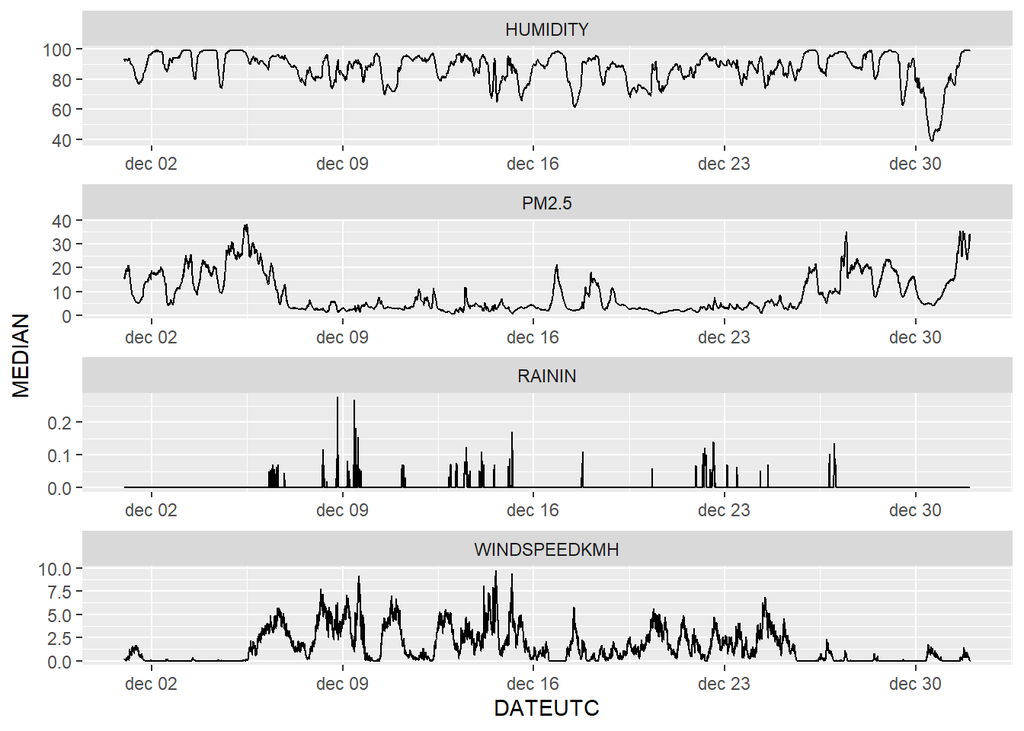

```r
ggplot(meteo_2019_09_med, aes(x = DATEUTC, y = MEDIAN)) +
  geom_line() +
  facet_wrap(~VARIABLE, scales = "free", ncol = 1)
```

### Quick spatiotemporal analysis of Leuvenair data

The data collected by the different sensors in Leuven have a temporal, spatial and data component. Making them very challenging (en exciting) to work with! R provides several tools to work with high-dimensional data like these. Here, you will make a quick visualization of the fine particles in the Leuvenair dataset for the first week of December using the `spacetime` package. Some other useful packages to look into might be `rggobi` and `plotKML` for visual inspection of the data. The observations have already been loaded and prepared above (i.e., hourly medians).

First, you create a space-time full grid object by assigning a spatial, time and data component.

```r
# Get PM2.5 observations in vector format
PM2.5dats <- data.frame(vals = as.vector(t(PM2.5zoo_med)))

# Filter on the IDs in the air data
air_stations_sp <- air_stations %>%
  filter(SDS011ID %in% unique(air$SDS011ID))

# Air stations as sp object
air_stations_sp <- as(air_stations_sp, "Spatial")

# Create STFDF object
library(spacetime)
PM2.5st <- STFDF(sp = air_stations_sp,
                 time = index(PM2.5zoo_med),
                 data = PM2.5dats)
```

You create an visual representation of the `spacetime` object by applying the `stplot` function on the space-time grid.

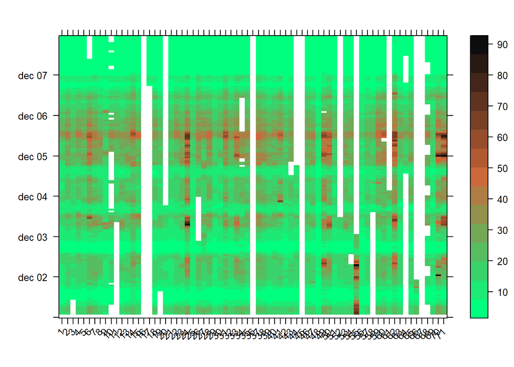

```r
# Visualise spatiotemporal data
airPal <- colorRampPalette(c('springgreen1', 'sienna3', 'gray5'))(5)
#
# Use stplot to create a spacetime visual
stplot(PM2.5st, mode = 'xt',
       col.regions = colorRampPalette(airPal)(15),
       scales = list(x = list(rot = 45)),
       ylab = '', xlab = '', main = '')
```

### Good luck during the KUL Datathon 2020!